# 当证明变得便宜，软件会发生什么？What Happens to Software When Proof is Cheap?

## AI 规格的挑战与实际解决办法AI Specification Challenges & Practical Solutions

幻灯片 86 Slide 86

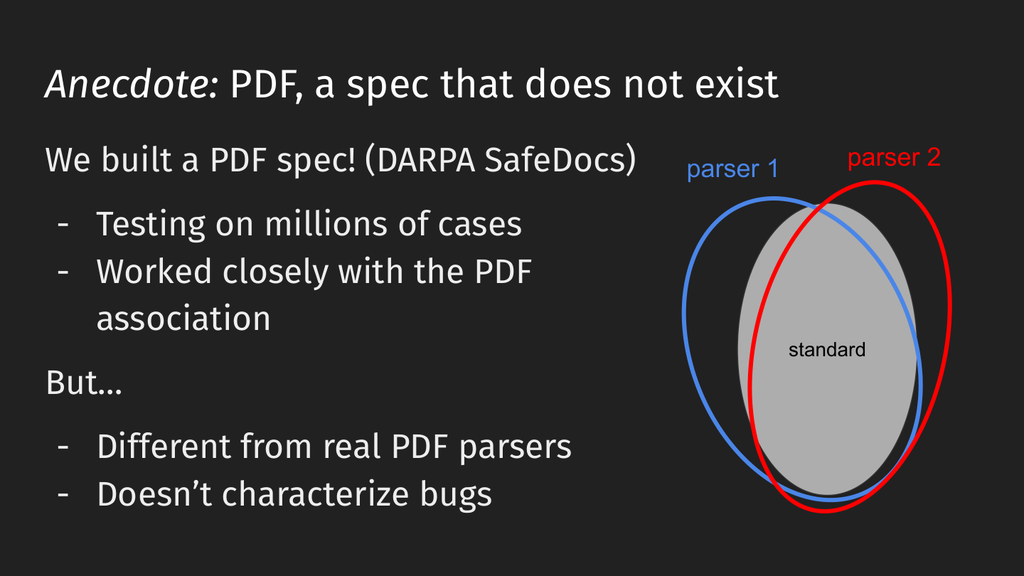

**幻灯片文字 / Slide text**

```
Anecdote: PDF, a spec that does not exist
standard
parser 1
parser 2
We built a PDF spec! (DARPA SafeDocs)
- Testing on millions of cases
- Worked closely with the PDF
association
But…
- Different from real PDF parsers
- Doesn’t characterize bugs
```

我们发现，PDF 有一份很好的规格，由 PDF Association 编写；但没有哪个实现，真正完全按照规格要求工作。它们之间存在一种很奇怪的关系：核心区域里，一切都说得通；可到了边缘情况，就不是这样了。And like we found what we found was that like PDF has a nice specification. It's written by the PDF Association, and none of the implementations do what the specification says they should do. They've all had this sort of funny like relationship where they're kind of like there's kind of a core where it all makes sense, and then there's these fringe cases.

我觉得，自己有点凝视深渊太久，最后意识到，所有东西都很难写规格，而且不清楚该怎么办。另一个问题是，怎样让 AI 帮助我们，把规格写对？如果想以这种方式使用规格，这种帮助将是必要的。And I sort of feel like, you know, I sort of stared into the abyss too much, and then I sort of realized that like everything's very hard to specify, and it's unclear what we do about that. Another thing is like how do we get the AIs to help us to get the specifications right? Like that's going to be necessary if we wanted to use specifications this way this way. Okay.

幻灯片 87 Slide 87

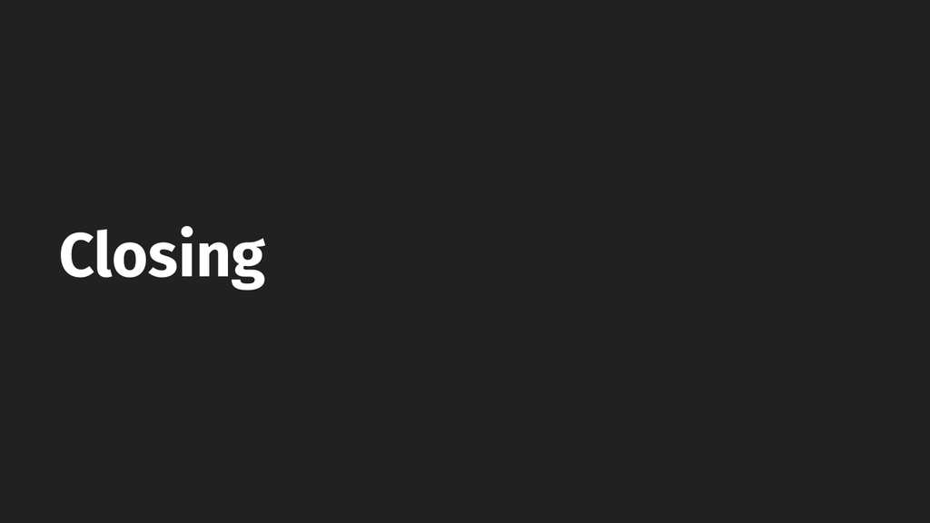

**幻灯片文字 / Slide text**

```
Closing
```

我准备稍微收尾了。关键在于，我们正在走向这样一个世界：AI 会解决很多我们原先认为与证明有关的问题，但仍然会留下很大的问题，需要解决。So, I think that's like, I'm going to sort of just you know, kind of close a little bit, but like I think the point is like, you know, there are like, you know, this the we are getting kind of like to a world where like AI is going to kind of solve a lot of the problems that we thought we had with proof. And there are still going to be some really big problems to solve.

这些问题中，很多看起来像形式化方法或编程语言领域的问题。当然，我这么说，也许有职业偏向。还有很多问题，涉及可用性、监督和信任。我觉得，我们应该确保，对这些问题给予关注，并投入精力。And like a lot of these problems, and I would say this, I suppose, they look like kind of formal methods PL type problems. A lot of them look like kind of usability or kind of like, you know, they look like kind of oversight problems. They look like trust problems. And I think that we should kind of like make sure that we kind of focus on those and like put effort into them.

**展开前面的幻灯片（88）Show preceding slides (88)**

幻灯片 88 Slide 88

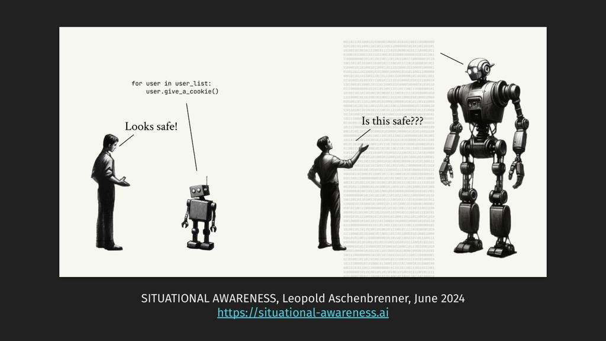

**幻灯片文字 / Slide text**

```
SITUATIONAL AWARENESS, Leopold Aschenbrenner, June 2024
https://situational-awareness.ai
```

- https://situational-awareness.ai

幻灯片 89 Slide 89

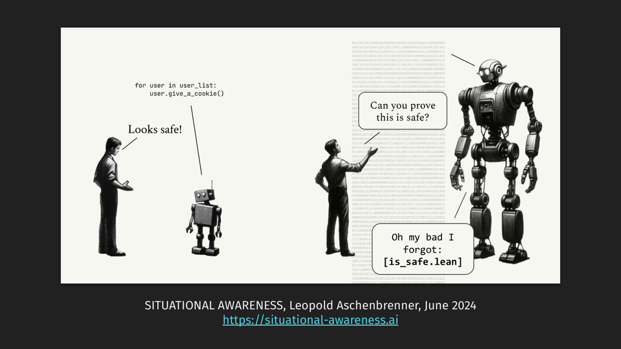

**幻灯片文字 / Slide text**

```
SITUATIONAL AWARENESS, Leopold Aschenbrenner, June 2024
https://situational-awareness.ai
Can you prove
this is safe?
Oh my bad I
forgot:
[is_safe.lean]
```

- https://situational-awareness.ai

我们可能面临这样的局面：AI 替我们构建了庞大、不可解释的系统。一个美好的世界是，你能说：“好，你能证明它安全吗？”AI 回答：“哦，当然，不好意思，这是证明。”你就说：“好，太好了。”So like this is the, you know, situation that we might be in, you know, we can have these large uninterpretable systems and the AI kind of builds them for us. Well, a nice world would be you could say, "Okay, well, can you prove this is safe?" And the AI is like, "Oh yeah, sorry about that. Yeah, of course, here's my proof, right?" And you're like, "Oh, okay, great.

“那我们继续。”能生活在这样的世界里，当然很好。但在到达那里之前，还有很多工作要做，还有很多困难问题要解决。Great, okay, let's keep going." This would be a very nice world to live in, but I think there's quite a lot to do before we could get to that world and there's quite a lot of hard problems to solve.

幻灯片 90 Slide 90

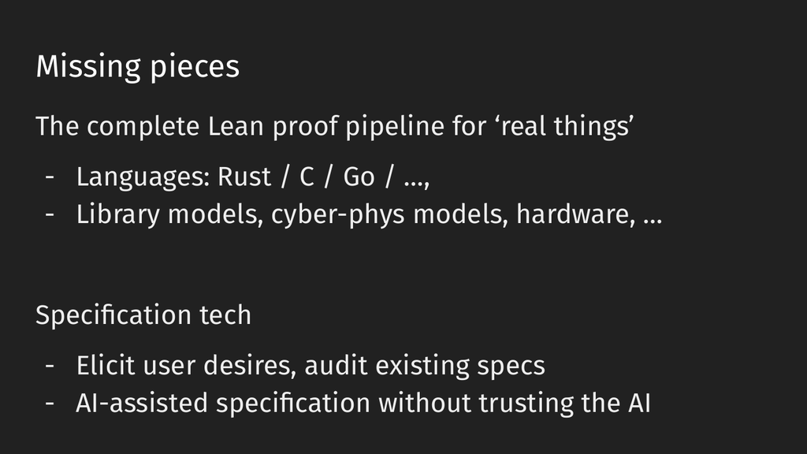

**幻灯片文字 / Slide text**

```
Missing pieces
The complete Lean proof pipeline for ‘real things’
- Languages: Rust / C / Go / …,
- Library models, cyber-phys models, hardware, …
Speciﬁcation tech
- Elicit user desires, audit existing specs
- AI-assisted speciﬁcation without trusting the AI
```

我觉得，还缺少一些关键部分。在 Lean 这条流水线上，Lean 很了不起，发展速度比我见过的任何形式化方法项目都快。但基础设施中，仍有很大一块缺失，还有很多组件没有补齐。如果你热衷于构建工具，我觉得，为 Lean 生态开发东西，是一个非常好的主意。So I think that some of the missing pieces are like we, you know, the in the Lean pipeline, Lean is amazing and it is moving quicker than I have ever seen like a formal methods project go, but there is still a large missing bit there are a lot of missing pieces in the infrastructure. If you are enthusiastic about building tools, I think building things in Lean is very good is a very good idea.

我支持“Lean 万物理论”：所有形式化的东西，都应该在 Lean 里构建；其他工具，也都应该移植到 Lean。不过，如果我们想真正解决某个现实问题，所需的很多组件，仍然没有准备好。I am a proponent of the Lean theory of everything, like everything you should just build all your formal things in Lean and like portal your other things to Lean. Um but I think that like, you know, sort of like we're still missing, you know, if we want to kind of hit some real thing, we're still missing quite a lot of the pieces that we would need to do that.

## 选择性取例Cherry Picking

还有一个非常重要的方向。如果你是一个聪明、有雄心的人，正在寻找一种不会仅仅因为 AI 变强，就自动被解决的问题，我认为，规格技术就是那个方向。And then I think that the big big thing that if you are an ambitious like smart person, you know, and you're looking for like the thing that will not be solved by AI getting better, like specification technology I think is the thing.

我们需要在这里，投入大量深入、审慎的工作，构建未来可能真正有用的工具。最后，我还想向大家推销一个疯狂困难、但我非常想做的项目。I think that's the place that we need like a large amount of kind of deep kind of thoughtful work to kind of build the tools that will be potentially useful for like kind of, you know, the future. Um one closing thing is I sort of wanted to pitch you all on my kind of like insanely hard thing that I would like to do, right?

幻灯片 91 Slide 91

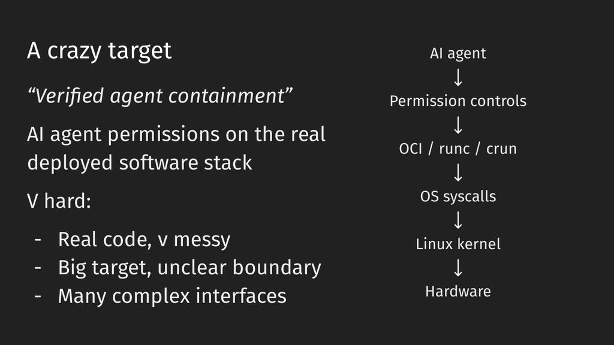

**幻灯片文字 / Slide text**

```
A crazy target
“Veriﬁed agent containment”
AI agent permissions on the real
deployed software stack
V hard:
- Real code, v messy
- Big target, unclear boundary
- Many complex interfaces
AI agent
Permission controls
OCI / runc / crun
OS syscalls
Linux kernel
Hardware
```

所以，[轻哼] 我真正想要的是，一个经过验证的智能体隔离系统。最顶层是 AI 智能体，下面是权限系统，经过 Docker 容器，再经过 OCI 层，再经过操作系统的系统调用、Linux 内核，最后到达硬件。然后，我们把所有东西都验证一遍。So — [snorts] — I would really like a sort of verified agents like containment system, right? You know, you what you have at the top is you have like an AI agent, it has a permission system that's like kind of like goes through a Docker container, that goes through this OCI layer, goes through the operating system system calls, it goes through the Linux kernel, and it goes to the hardware, and we verify everything, right?

我之前向一位在场的人推销过这个想法，很高兴看到他的反应是：“这不是一个可能实现的项目。”不过，我也不知道。如果我们真有非常擅长证明的智能体，也许可以想象，去做这么疯狂的事情。但这意味着，我们必须问：到底还缺什么？This is, you know, I sold someone earlier this and like it's good to see them being like, "This is not a possible project." But like I don't know. I think like suppose we have like agents that are just good at proof. Maybe we could sort of imagine what we're doing this kind of thing, like something as kind of crazy as this. But I think it means we have to ask like well, what's missing?

## AI 证明：信任、可靠性与人类判断AI Proofs: Trust, Reliability, and Human Judgment

缺少的是，我们需要处理大量真实系统代码，需要在 Docker 层面、操作系统内核层面，以及内核内部接口层面，提取规格。所有这些事情，都需要广泛使用 AI 辅助。今天，我们还没有这些工具，真的需要把它们构建出来。And what's missing is like we would need like to be able to deal with a lot of real system code. We would need to be able to kind of like elicit specifications at the Docker level, at the operating system kernel level, internal kernel interfaces. Like all of these things are things where we would need AI assistance pervasively. We don't have those tools today. We really need to build them. So.

幻灯片 92 Slide 92

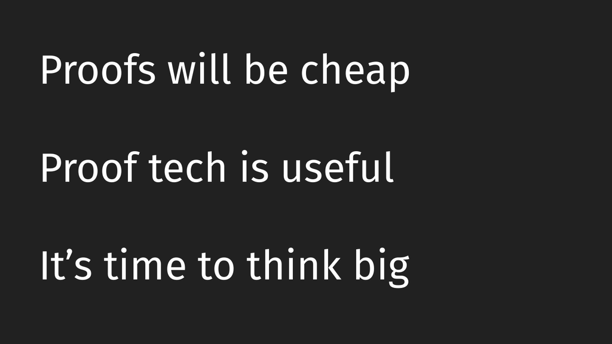

**幻灯片文字 / Slide text**

```
Proofs will be cheap
Proof tech is useful
It’s time to think big
```

我觉得，证明会变便宜；证明技术非常有用；现在应该大胆思考，而且有很多工作要做。谢谢大家！Yeah, I think proofs are going to be cheap, and I think proof tech is very useful, and it's time to think big, and I think there's a lot to do. THANK YOU.

幻灯片 93 Slide 93

[figure not shown]

**幻灯片文字 / Slide text**

```
What Happens When
Proofs Get Cheap?
Mike Dodds - Galois, Inc.
```

[掌声] [掌声][applause] [applause]

Zach好，各位，我想我们还有时间提几个问题。Pedro。UH OKAY, EVERYBODY. I THINK WE HAVE TIME FOR SOME QUESTIONS, PEDRO.

Pedro你谈了很多关于验证 AI 证明的事情。但我想，你是否过于贴合 AI 目前的状态来思考了？因为 AI 生成的证明，本来就不应该需要再验证。SO, you talked a lot about verifying AI proofs. But I wonder if you're over fitting to the current state of AI because AI proof shouldn't need verifying.

AI 应该能够生成证明，不需要比编译器输出更多的验证。AI should be able to produce proofs that don't need any more verification than, you know, than a compiler output.

Mike Dodds你是说，AI 已经非常可信，总能给出正确证明，我们从不需要怀疑它。Yeah, you mean like the AI sort of is like it sort of it's so trustworthy that it always gets the proof right, and we never have to doubt it.

Pedro找到证明的过程，涉及大量机器学习和搜索。但最终生成的证明，其中每一步，都可以保证正确。完全没有理由认为，这不可能实现。There's a big search process with all the machine learning and blah blah for the proof, but the proof that it produces, every step of it, you know, is guaranteed to be correct. There is absolutely no reason that shouldn't happen.

Mike Dodds对，我觉得，部分原因还是审计。AI 可能非常可靠，但有 Lean 这样的证明检查器，仍然很好，因为我们可以审视信任根，而这个信任根，不依赖 AI 自身。它是一个独立的信任根。Yeah, I mean I think that I think it's I think part of it is just like audit, I suppose, like you know, so it might be that the AI is very reliable, but having like a proof checker like Lean is very nice because then we can we can look at the kind of root of trust and it doesn't rely on the AI itself. So, it's sort of like separate like root of trust.

当然，我也认为，最终出现几乎从不犯错的 AI，是完全可能的。那也会是一个非常美好的世界。只是，我不确定自己是否完全相信，它一定会发生。但确实，有这种可能。Um but I mean, I think it's totally plausible that we'd end up with AIs that are that are so good that they essentially never make mistakes. I mean, that would be a wonderful world to live in as well. Um I don't know if I'm like I don't know if I like fully believe that's that's going to happen. Right. Yeah, I mean, that that could be the case.

## 教学工具的演变：全球视角The Evolution of Teaching Tools: A Global Perspective

从一个角度说，这种愿景其实偏悲观，有点像 AI 控制的思路：如果 AI 始终不可靠，却很强大，会怎样？我觉得，这是可能的。但也许，我们生活在一个 AI 既非常可靠、又非常强大的世界里。这当然也可能。I mean, I think it's I think that this is like in one way like this vision is kind of like a pessimistic vision. It's a bit like kind of the sort of control AI control idea that what happens if the AI remains kind of like unreliable but powerful, and I think that's possible. But maybe we live in a world where the AI is very reliable and very powerful. That's certainly possible.

Audience非常感谢你来给我们做报告，我很喜欢。我听完之后，一个想法是：我们需要教更多人 TLA+，或者 Forge、Alloy、Lean，总之是完成任务所需的某种组合。过去，要编写这类代码，往往得在相应领域拿到博士学位。Yeah, thanks so much for coming to speak with us today. I really enjoyed the presentation. In my mind, and one outcome of what your talk said is, "Hey, we need to be teaching more people TLA+ or I don't know, Forge, Alloy, Lean, whatever you know, combo you need there." And it used to be the case that you needed a PhD in that thing to write that kind of code.

现在，我们看到本科课程不断出现，Lean 也正在数学领域变得更加大众化。从 Galois 的角度看，你们怎样培训大家使用这些工具？公司里的学习曲线是什么样的？对于华盛顿大学来说，在教授规格、建模、形式化验证等内容时，有哪些经验值得借鉴？And now we're seeing undergrad classes pop up and kind of Lean being democratized across math. I'm curious in your perspective at Galois, like, how are you training people to use these kinds of tools? What does the learning curve look like at the company, and are there learnings that we should have at U Dub about how we should be teaching people about specification, modeling, formal verification, all that kind of stuff?

Mike Dodds这是个很好的问题。今天午饭时，我们刚聊过，相关课程体系应该是什么样。我学习使用这些工具的方式，基本上就是直接使用。Yeah, I think that's a great question. We were just talking about this over lunch, like, what does the kind of curriculum look like for this? Uh so, I am I mean, the way I've learned to use these tools is really just by using them.

很难给出长期有效的建议，因为今天的 Claude，与六个月前不一样，更不用说一年前。I think there's like it's very hard to sort of give like durable advice because what cloud is like today is not what cloud was like 6 months ago and it's not what it was like really not what it was like a year ago.

我觉得，研究如何教大家使用这些工具，非常有价值。我对一个定理是不是胡说八道，有某种直觉，但这种直觉，并不容易传授给别人。Um, I would say that like very good I think that figuring out like how we should like teach people to use these tools and also like you know, like I get I have a kind of gut sense like when a theorem is nonsense, you know, but that sort of gut sense is not a very portable thing, right?

我不知道，怎样快速教会别人这一点。如果你在思考这些问题，我会说，这片空间仍然非常开放。I don't know how to kind of teach someone that quickly and I think that I think I think if you're thinking about these questions, I would recommend like, you know, the space is wide open.

## 第 1 章：“Rust 的证明工具与代码质量Ch 1: "Rust's Proof Tools vs. Code Quality

我会建议，先用这些工具，看看什么有效，再思考下一步。你很可能是第一个提出某个问题、或者研究某个问题的人，这非常令人兴奋。不过，除此之外，我没有太多建议：拿起工具，用它们去解决实际问题。I would try I would use the tools and see what works and then see how, you know, you probably you may be the first person to ask that question or work on that problem and this is very exciting, but I don't really have much more advice before beyond just kind of pick the tool up and hit things with them.

Audience你的报告让我很有共鸣，因为我维护的是规模非常大、规格非常不完善、而且需要长期维护的遗留系统。现在，很多人会提交非常大的 AI 生成拉取请求。它们可以被验证，因为我们有很好的测试，知道它们相对于现有实现，通过了已有测试，因此新的 Rust 实现是正确的。So, your talk really resonated me with me because I work on very large, very poorly specified legacy systems and they need to be maintained for a really long time. And we what we've been getting is a lot of people submitting these very large AIPRs and they can be verified because we have good tests and we know that they pass existing tests against an existing implementation so the new rust implementation is correct.

但我们仍然需要花很多时间审查，确保代码可维护，并且在更偏定性的意义上也正确，比如使用良好的命名约定，以易维护的方式组织。所以，有没有办法，利用这些证明，验证可维护性，以及编程作为一门“艺术”的那些定性方面，而不只是科学意义上的“它是否正确”？But, we still spend a significant amount of time reviewing them to make sure that they're maintainable and more qualitatively correct in a way that, you know, they use good naming conventions and they're written in a way that is maintainable. So, is there a way to use these proofs to verify the maintainability and the more qualitative aspects of the art of coding rather than the science of is it actually just correct?

Mike Dodds这里确实有一个很有意思的二分：你是否把一段代码，看成一种可以随时丢弃的东西？它只是内部实现，是三明治中间的馅料。Yeah, I mean, I think there's I yeah, I think that there's like this interesting dichotomy between sort of like, do you see like a sort of piece of code as like a sort of disposable thing, you know, it's just like, you know, it's the inside, you know, it's the filling in the sandwich, right?

还是说，你在乎它是否组织得漂亮？我们今天的证明工具，其实不太面向代码质量。很多时候，可证明的代码，写得确实比较清楚，因为这样更容易推理。Or do you care that it's like nicely structured and so I think the AI is often you know, I think it I I think it's like I don't the proof tools that we have today are sort of they're not really very oriented towards like code quality, right? Often it's the case that like provable code is reasonably nicely written because it just makes it easier to think through.

我觉得，建立更严格的方法，评估代码是否可维护、是否符合语言惯用写法，非常有意思。不过，我也不知道该怎么解决。Um I think that I think it's sort of I think having more rigorous ways to like evaluate whether or not something is going to be sort of maintainable, idiomatic is really interesting and I don't know how to kind of solve that either.

## 算法设计中安全性与简洁性的权衡The Trade-Off Between Security and Simplicity in Algorithm Design

某种意义上，这也是一个规格问题：你能否读懂代码，能否通过阅读代码，提取出它的含义？这又是一个很有意思、尚未解决的问题。That also seems like a it's a kindness back problem in a sense cuz like can you read the code and understand it is like a sort of can you elicit what it means from like reading the code? Um yeah, I think it's a again very interesting unknown thing.

Audience谢谢，报告非常好，也很有启发性。不过，我还想追问刚才那个问题。Oh, thank you. Great presentation actually, very inspiring. But I still carry that question.

如果你证明了某个算法在逻辑上很好，是否真的意味着它安全？比如，我刚才说的时序攻击、故障注入、功耗攻击，以及这些工程层面的技术。对于 Galois 这样的公司，在工业界，你们如何处理这些问题，或者开展相关审计？So basically, if you're proving a certain algorithm that is like logically good, does it really mean that it's secure, right? Like like I talk about like time timing and glitching, power tags, all those kind of engineering techniques. Um so for your company like Galois, yeah, how do you guys actually process those or like do those audits in the industry?

Mike Dodds对，这正是一种内在权衡。我之前在这里做过一次报告，提出过：当你完成形式化验证时，不应该说“系统里没有缺陷”，因为你做了假设。比如，假设没有时序信道，或者其他类似假设。Yeah, I think that yeah, this is this is kind of you know, this is the sort of inherent trade off. Like you know, so I gave a talk here a while back where I sort of said like you shouldn't say when you formally verify something there are no bugs in the system because what happened because like you're making assumptions. Like for example, you're assuming no timing channels or you're assuming no kind of whatever.

这些都是建模假设，或者你假设所用的库正确。总会存在一个边界。与委托你工作的人沟通时，应该说明：“我们是在这些假设下工作的，而这些是由这些假设得到的结论。”And those are kind of modeling assumptions or you're assuming your libraries are correct. There's always going to be a sort of interface. I think that trying to like sort of communicate with the person you're doing the work for like well, these are the assumptions we're operating under, these are the consequences of these assumptions.

因此，在这个范围内，我们可以以合理的信心排除缺陷；但比如对于时序特性，我们完全没有作出任何保证。我觉得，这类工作中，这是一种好的实践。So we can rule out bugs with reasonable confidence within this kind of area, but like we don't say anything at all about like the timing characteristics, for example. I think that's kind of a good practice when you're trying to do this sort of work.

难点在于，为了让验证成为可能，你必须作出一些假设；但缺陷，很可能恰好位于你没有覆盖的区域。比如，我提到的 Lean 缺陷，就在运行时里，而它属于 Lean 内核相关实现中未经验证的部分。Um it is like it's sort of the thing that's very hard about this, I suppose, is that you have to make some assumptions to make it possible to do this sort of like verification, but the bugs are probably in the area you didn't like, you know, in the case of the Lean bug that I pointed to, the bug was in the runtime, which is an unverified bit of the Lean kernel.

## 计算机科学中证明方法的局限The Limits of Proof Methods in Computer Science

无论把边界放在哪里，总有边界之外的东西，不在你的处理范围内，需要用其他方式应对。所以，你必须清楚，自己在哪些地方只是作了假设。这又是一个很难处理的问题，基本上属于规格问题的一部分。And so, wherever you kind of put your boundary, there'll be things outside of the boundary that you don't deal with, and you got to have some other way of dealing with that. So, you got to you got to kind of go in knowing what you're guessing. So, I think it's like again, like a hard thing to kind of deal with. It's like part of the specification problem, basically.

Zach能再回答一个问题吗？Can you do one more?

Audience非常有意思。我想问，这类证明方法、证明技术的局限在哪里？尤其是，它能处理输入不确定的算法、随机化算法吗？比如，要证明一个人脸识别算法是正确的，在我看来似乎不太可能。所以，这些形式化方法的边界在哪里？这是第一个问题。Um very interesting. Um I was wondering what are the limits of this class of proof methods proof techniques? In particular, can it deal with algorithms that handle uncertain input, algorithms that are randomized? Um like it doesn't seem to me plausible that one would be able to prove that a face recognition algorithm is correct. So, where are the limits of of these, you know, formal methods? So, that's one question.

第二个问题，关于报告的前半部分。你说，数学证明可能会变得容易。那么，定理呢？总得有人提出定理。Second question, about the first part of your talk, you said that, you know, math proofs may become easy. I'm curious, what about the theorems? Somebody has to come up with the theorems.

Mike Dodds对，关于第二个……先说第一个问题，我觉得你说得对。很多时候，如果我们说“人脸识别算法正确”，那“正确”究竟是什么意思？Yeah, I think on that second on the first question, I think you're right. Like, you know, there are lots of things where you know, if we say like, "Oh, our our our facial recognition algorithm is correct." Um well, what does correct mean?

我们并没有一个关于“人脸究竟是什么”的数学定义。这也正是我们需要这类数据科学算法的原因。It's like, well, we don't have like a mathematical definition of what the human face is. That's kind of the reason we need these kind of data science algorithms, right?

也许，你可以说：“算法不会以我不希望的方式泄漏数据。”或者：“对于这个算法，我们有一个明确的定义，而实际代码，确实按照算法所声明的方式工作。”I suppose you might be able to say that like my algorithm doesn't leak data in a the way that I don't want or my algorithm implements like the kind of like, you know, the there's a specific there's a definition of what the algorithm should be and the real code does exactly what the algorithm claims.

但如果我们想验证一辆自动驾驶汽车，该怎么规定“它永远不会撞车”？这时，你需要一个覆盖整个世界、覆盖所有可能运行情境的模型，而这并不是我们真正能够做到、能够验证的东西。Um but there's going to be like the world's, you know, if you we're trying to verify a self driving car, well, how do you specify that it always kind it never crashes? Well, in that case you need a model of the entire world of like all the situations it can possibly operate in and that's like not a thing that we can verify we can really do.

所以，关键更像是：我们想要的东西，是否存在一种清晰、明确的表达方式？这仍然覆盖一大类需求，但也有边界。你永远不可能摆脱人们所说的 V&V，也就是确认与验证。其中，确认这个环节，不会消失。So, it's sort of more like is there a kind of crisp way of specifying the thing that we want? That's still a big category of things that we might want, but it's limited. It's like it's you you're never going to get rid of like what people call like V&V, kind of like, you know, validation and verification. Like the validation is not going to go away.

第二个问题是：定理从哪里来？比如，为什么人们想知道考拉兹猜想的答案？并不是 AI 自己想知道，是我们想知道。Um So, the second question you're asking about like where do the theorems come from? Yeah, this is like I mean, well, why do people find, you know, why does why do why do we want answers to that you know, the sort of Collatz conjecture, right? You know, I mean, it's not like the AI can want that, right? You know, it's like we want that.

这是一种人类产生愿望、形成需求的过程。我觉得，它必须来自我们。当然，如果 AI 足够强，我完全可以想象，它会说：“我找到了一批有意思的定理……”But like that's sort of a human process of like desiring or wanting, right? You know, it has to come from us, I think. Um I could definitely imagine that you know, we suppose that like the AIs are very good that they might do sort of like they might sort of say, "Okay, well, here's a bunch of interesting theorems that I found.

“你关心这些吗？”作为数学家，这可能很有用。但我也觉得，我用 AI 构建项目，是因为自己关心这些项目；之所以做，是因为我在乎。这种动机，我认为仍然会来自人类。Do you care about these ones, you know?" That's kind of a matter you know, it would be a useful thing potentially as a mathematician. But I also think that like a good reason to you know, when I build use the AI, use it to build projects I care about and like the reason I do them is because I care about them, right? That's going to come from like humans, I think.

Zach好，让我们再次感谢 Mike。Okay, let's thank Mike again.

[掌声][applause]